# Differential Diagnosis of PD, PSP, and MSA: An XGBoost Approach to Retinal Layer Analysis

[figure not shown]

# Differential Diagnosis of PD, PSP, and MSA: An XGBoost Approach to Retinal Layer Analysis

**M. Rodriguez-Rubio¹, F.J. Martinez-Murcia¹, J. E. Arco², I. A. Illán¹, F. Segovia¹, C. Jimenez-Mesa¹, C. Vazquez-Garcia¹, J.M. Gorriz¹, J. Ramirez¹, S. Schönecker³, S. Kamp³, L. Klatte³, S. Katzdobler³, L. Marth³, O. Wagemann³, C. Palleis³, U. Fietzek³, E. Weidinger³, A. Danek³, G. Hölinger³, J. Havla³, A. Bernhardt³, A. Jäck³, J. Levin³**[cite: 1]

*¹Andalusian Research Institute in Data Science and Computational Intelligence (DaSCI), University of Granada, Spain | ²Mind, Brain and Behavior Research Center (CIMCYC), Granada, Spain | ³Department of Neurology, LMU University Hospital, Ludwig-Maximilians-Universität München, Munich, Germany*[cite: 1] {.text-secondary}

## 1. INTRODUCTION

**Clinical Challenge:** Parkinson’s disease (PD), progressive supranuclear palsy (PSP), and multiple system atrophy (MSA) share overlapping clinical presentations in early stages, making differential diagnosis challenging[cite: 1].

**Underlying Proteinopathies:** PD and MSA are characterized by alpha-synuclein aggregation (**synucleinopathies**), whereas PSP involves pathological tau deposition (**tauopathy**)[cite: 1].

**The Retina as a Window to the CNS:** Optical coherence tomography (OCT) enables precise, non-invasive quantification of individual retinal layers, reflecting pathology-specific thinning patterns[cite: 1].

**Objective:** We present a systematic machine learning evaluation using **XGBoost** across four classification tasks to distinguish healthy controls, proteinopathic groups, and clinical subtypes from OCT retinal morphometry[cite: 1].

## 2. METHODOLOGY

Macular records were acquired and segmented using the **Heidelberg Spectralis OCT** device[cite: 1]. Only baseline high-quality visits per patient were included, averaging both eyes to represent bilateral neurodegenerative involvement[cite: 1]. A total of **29 morphometric features** were extracted, normalized at the subject level by total macular volume ($\text{TMV}+Z$), and standardized ($Z\text{-score}$).

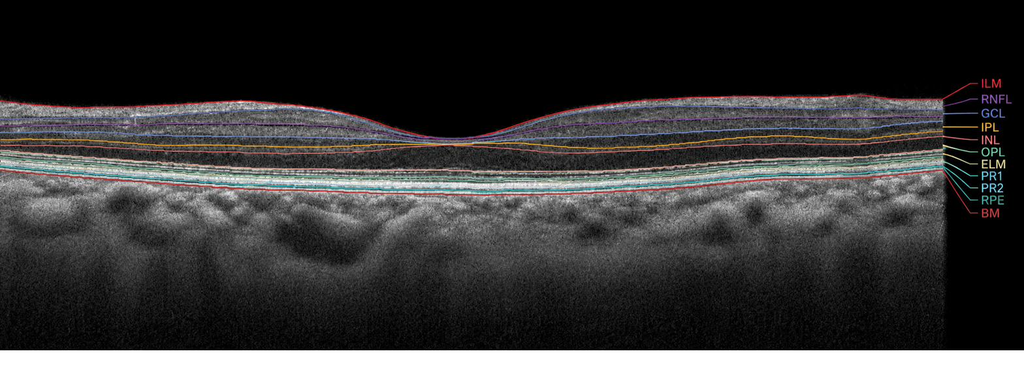

**Fig 1.** Automated segmentation of macular retinal layers (RNFL, GCL, IPL, INL, OPL, ONL, RPE) via OCT.[cite: 1] {.text-secondary .mb-0 .mt-2 style=“font-size: 20pt; text-align: center;”}

### 2.2 CLASSIFICATION FRAMEWORK (XGBOOST)

**Macular OCT**[cite: 1]  
9 Layers + IRL, ORL, TMV[cite: 1, 2]

↓

**Preprocessing**  
29 Features | $Z$ vs $\text{TMV}+Z$[cite: 2]

↓

**XGBoost**[cite: 1, 2]  
$10 \times 5\text{-fold}$ Stratified CV[cite: 2]

**Fig 2.** OCT feature extraction and ML pipeline. {.text-secondary .mt-2 .mb-0 style=“font-size: 19pt; text-align: center;”}

Classification was conducted using the **eXtreme Gradient Boosting (XGBoost)** algorithm evaluated via repeated 5-fold stratified cross-validation ($10 \times 5\text{-fold}$ CV)[cite: 2].

**Four Diagnostic Tasks Evaluated:**[cite: 1, 2]

- **HvP:** HC ($N=36$) vs. Parkinsonism ($N=98$)[cite: 2].
- **SvT:** Synucleinopathies (PD+MSA, $N=64$) vs. Tauopathy (PSP, $N=34$)[cite: 2].
- **3-Class (3C):** PD vs. PSP vs. MSA ($N=98$)[cite: 2].
- **4-Class (4C):** HC vs. PD vs. PSP vs. MSA ($N=134$)[cite: 2].

### 2.1 DATASET AND PARTICIPANTS

From 488 initial records (186 participants), individuals with low-quality estimations or missing values were discarded, resulting in **134 subjects**[cite: 1]:

[output not shown]

Nine macular layers were segmented (RNFL, GCL, IPL, INL, OPL, ONL, RPE)[cite: 1], alongside inner/outer retinal layer aggregates (IRL, ORL), total macular volume (TMV), ETDRS grid ring zones, and the RNFL-to-NT ratio[cite: 2].

## 3. RESULTS

### Classification Accuracy across Tasks

The *raw* feature set consistently outperformed PCA-reduced inputs (10 components) across all experiments[cite: 2]. {.text-secondary .mb-4 style=“font-size: 21pt;”}

**HvP (Binary)**  
HC vs. Rest ($Z$, *raw*)[cite: 2]

**72.4%**[cite: 1, 2]  
± 7.9%[cite: 1, 2]

**SvT (Binary)**  
PD+MSA vs. PSP ($\text{TMV}+Z$)[cite: 2]

**70.4%**[cite: 1, 2]  
± 5.7%[cite: 1, 2]

**3-Class (3C)**  
PD vs. PSP vs. MSA ($\text{TMV}+Z$)[cite: 2]

**52.1%**[cite: 1, 2]  
± 10.0%[cite: 1, 2]

**4-Class (4C)**  
HC / PD / PSP / MSA ($Z$)[cite: 2]

**39.5%**[cite: 1, 2]  
± 12.0%[cite: 1, 2]

### Classification Performance Summary (Mean ± SD, $10 \times 5\text{-fold}$ CV)[cite: 2]

| Task | Norm. | Set | Accuracy | Bal. Acc. | F1-Macro |
| --- | --- | --- | --- | --- | --- |
| **HvP** (HC vs. Rest)[cite: 2] | $Z$[cite: 2] | *raw*[cite: 2] | **$0.724 \pm 0.079$**[cite: 1, 2] | $0.609 \pm 0.064$[cite: 2] | $0.619 \pm 0.073$[cite: 2] |
| **SvT** (PD+MSA vs. PSP)[cite: 2] | $\text{TMV}+Z$[cite: 2] | *raw*[cite: 2] | **$0.704 \pm 0.057$**[cite: 1, 2] | $0.650 \pm 0.071$[cite: 2] | $0.652 \pm 0.071$[cite: 2] |
| **3-Class** (PD/PSP/MSA)[cite: 2] | $\text{TMV}+Z$[cite: 2] | *raw*[cite: 2] | **$0.521 \pm 0.100$**[cite: 1, 2] | $0.472 \pm 0.105$[cite: 2] | $0.440 \pm 0.111$[cite: 2] |
| **4-Class** (HC/PD/PSP/MSA)[cite: 2] | $Z$[cite: 2] | *raw*[cite: 2] | **$0.395 \pm 0.120$**[cite: 1, 2] | $0.374 \pm 0.110$[cite: 2] | $0.354 \pm 0.112$[cite: 2] |

**Impact of TMV Normalization:** Including subject-level TMV normalization ($\text{TMV}+Z$) specifically enhanced the separation of symptomatic cohorts, boosting **SvT** accuracy from $0.622 \pm 0.065$ ($Z$) to **$0.704 \pm 0.057$** ($\text{TMV}+Z$)[cite: 2].

## 4. KEY FINDINGS & CONCLUSIONS

- **Robust Biological Stratification ($\approx 70\%$):** The XGBoost framework effectively distinguishes synucleinopathies (PD+MSA) from tauopathies (PSP) ($0.704 \pm 0.057$), comparable to binary HC vs. pathology discrimination ($0.724 \pm 0.079$)[cite: 1, 2].
- **Divergent Retinal Signatures:** Findings confirm that alpha-synuclein and tau pathology exert divergent neurodegenerative pressures on inner and outer retinal architecture[cite: 2].
- **Multiclass Phenotypic Overlap:** Performance in 3-class ($0.521$) and 4-class ($0.395$) settings highlights the significant morphological and clinical overlap between PD and MSA[cite: 1, 2].
- **Clinical Translation:** Combining OCT biomarkers with machine learning paves the way for faster, non-invasive, and cost-effective early-stage stratification in atypical parkinsonism[cite: 1, 2].

**Funding:** Projects PID2022-137629OA-I00, CNS2024-154296, PID2022-137451OB-I00 (MICIU/AEI/10.13039/501100011033 & ERDF/EU), TIC251-G-FEDER, grant RYC2021-030875-I (NextGenerationEU/PRTR), Friedrich-Baur-Stiftung, and LMU “FöFoLe” Program[cite: 1].  
**References:** [1] C. Palleis et al., *Brain*, 2026[cite: 2]; [2] N. Mammadova et al., *Biomedicines*, 14:249, 2026[cite: 2]; [3] P. Visser et al., *Appl. Sci.*, 14:2491, 2024[cite: 2].

**Contact:** `fjesusmartinez@ugr.es` | Signal Processing and Biomedical Applications (SiPBA)[cite: 5, 8]